# Causal Inference Report: Review on Child Penalty

Juan Pablo Brasdefer

Fabian Pawelczyk

2023-05-24

The estimand: Impact of children on the labour market outcomes of women relative to men. *I wonder whether labor market outcomes is precise or earnings are better* Research gap: most research sheds light into local effect of a second or third chilf but they cannot provide estiamtes of the total effect of children and especially the first child

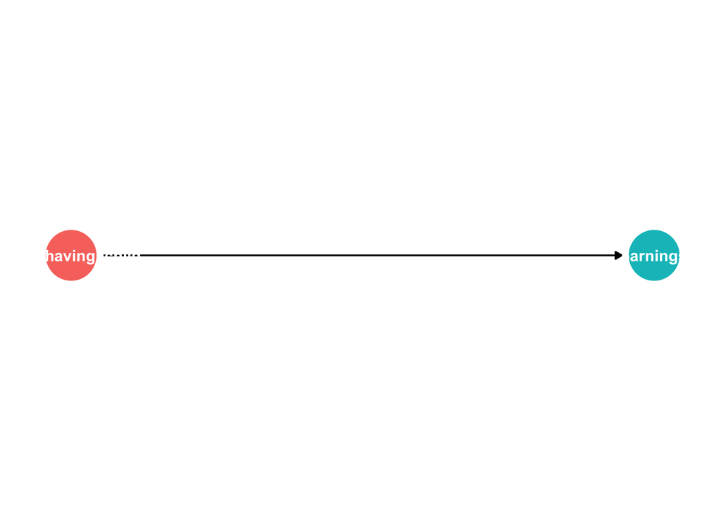

```r
# The estimand as a DAG
estimand_dag <- dagify(earnings ~ birth_having_child,
                        outcome = "earnings",
                        exposure = "birth_having_child",
                        coords = list(x = c(birth_having_child = 1, earnings = 2),
                                      y = c(birth_having_child = 1, earnings = 1)))

ggdag_status(estimand_dag) +
  theme_dag() +
  guides(color = "none")  # Turn off legend
```

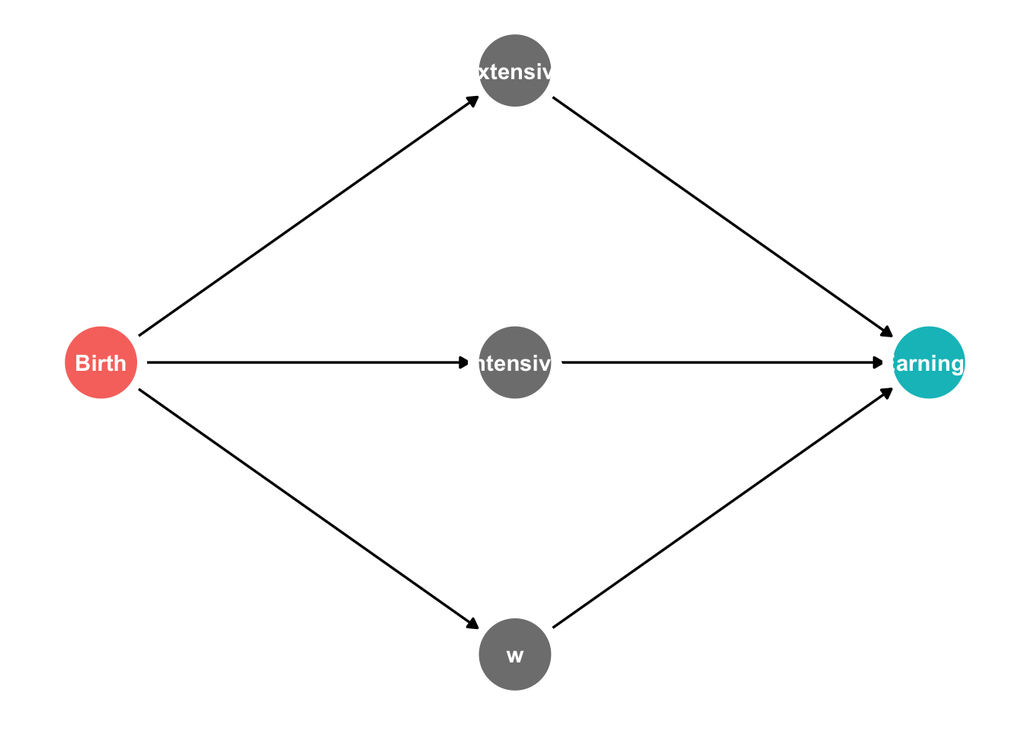

```r
# Define the DAG
dag <- dagitty( 'dag {
  "Birth" [exposure,pos="0,0"]
  "Earnings" [outcome,pos="2,0"]
  "Extensive" [mediator,pos="1,1"]
  "Intensive" [mediator,pos="1,0"]
  "w" [mediator,pos="1,-1"]
  "Birth" -> "Extensive"
  "Birth" -> "Intensive"
  "Birth" -> "w"
  "Extensive" -> "Earnings"
  "Intensive" -> "Earnings"
  "w" -> "Earnings"
}' )

# Print the DAG
ggdag_status(dag) +
  theme_dag() +
  guides(color = "none")
```

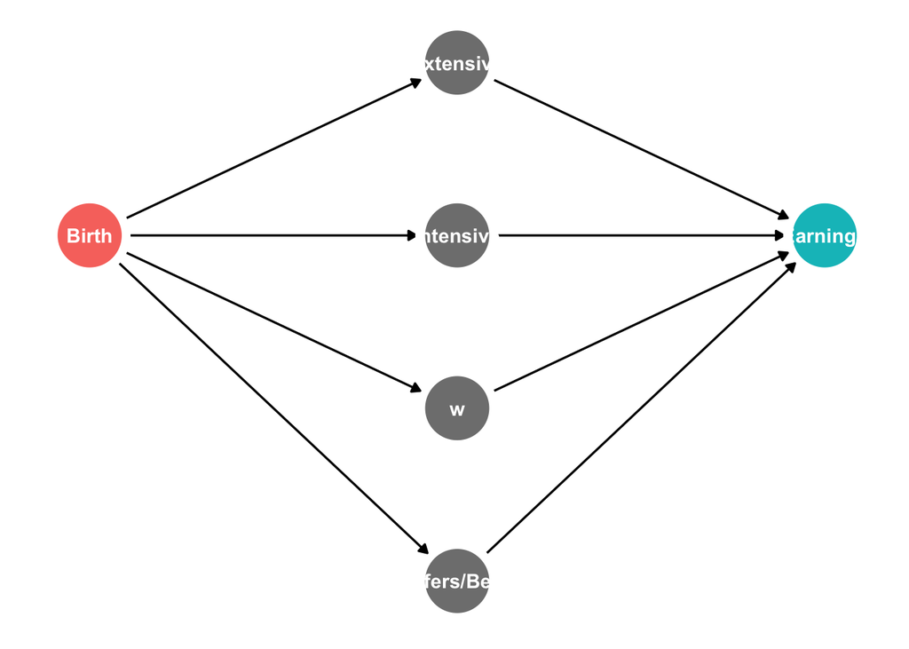

```r
# Define the DAG
dag1 <- dagitty( 'dag {
  "Birth" [exposure,pos="0,0"]
  "Earnings" [outcome,pos="2,0"]
  "Extensive" [mediator,pos="1,1"]
  "Intensive" [mediator,pos="1,0"]
  "w" [mediator,pos="1,-1"]
  "Transfers/Benefits" [mediator,pos="1,-2"]
  "Birth" -> "Extensive"
  "Birth" -> "Intensive"
  "Birth" -> "w"
  "Birth" -> "Transfers/Benefits"
  "Extensive" -> "Earnings"
  "Intensive" -> "Earnings"
  "w" -> "Earnings"
  "Transfers/Benefits" -> "Earnings"
}' )
# Print the DAG
ggdag_status(dag1) +
  theme_dag() +
  guides(color = "none")
```

# Second, thinking about the data

The study conducted in the 2019 paper (the paper which we are focusing on) works as a form of Natural Experiment, as the births and decisions around work occur have occurred in the natural world. Data for Austria, Denmark, and Sweden is taken from administrative registers that hold data for the full population, while Germany, the US, and the UK use surveys with sufficiently large sample sizes and long time series. Though the authors highlight the fact that “the ideal experiment for the estimand would be to randomize fertility”, the study has several key aspects that work positively for it as a Natural Experiment.

First, there is exogenous assignment of treatment (people have babies long before the study begins), meaning that assignment is not subject to manipulation. Childbirth occurs naturally, though it is important to note that the authors chose to ONLY include treated individuals (child = true) in the study, and develop counterfactuals statistically instead of as natural data points. This is further explored in the Identification section later on.

Second, data collection for purposes of the survey takes place after the data itself has been generated, meaning that there is no opportunity for the researchers to influence the data or response of individuals.

Third, confounder bias is largely made negligible by the pool of data. Something could be said about participation bias when it comes to those who do and do not answer surveys, but the authors do not see this as a hindrance, given a very big sample size and frequent data.

For the remainder of the Methods, and Identification sections, it is important to note that this paper bases its approach on a previous paper by Kleven et al. from 2018. Data collections is dissimilar, but the statistical formulations and approaches to bias reduction and variable control are the same.

# Methods: Event Study Framework

The paper follows an Event Study Framework, meaning that the focus of the study is to note changes in variables before and after a precise event.

With regards to choosing Event Study as the study design, the authors recognize that, “although fertility choices are not exogenous”, the effects of having a first child create changes in labour market outcomes that are “arguably orthogonal to unobserved determinants of those outcomes”. Said differently, we expect the unobserved determinants to evolve smoothly over time, regardless of birth.

Thus, this event study relies on the Smoothness Assumption (especially for identifying the short-run effects). The smoothness assumption tells us that the events happen in a continuous manner without abrupt jumps or discontinuities.

The precise event in question is the birth of the first child, around which event-time ‘t’ is centered. The Event Window extends backwards 5 years and forward 10 years on an individual basis so that t = (-5,-4…0…9,10) denotes the distance from the birth of each person’s first child. The birth of the child for individual ‘i’ is independent of other time or age measurements and the births of other children. One thing to note is that t = -1 is not included in measurements, as it incorporates the effects of pregnancy on a woman that men do not experience.

# Methods: Baseline Regression Model

In order to circumvent this in the baseline model, the authors create the regression equation below.

$$Y^{g}_{\text{ist}} = \sum_{j \neq -1}
\alpha^{g}_{j} \cdot I[j = t] + \sum_k \beta^{g}_{k} \cdot I[k =
\text{age}_{is}] + \sum_y \gamma^{g}_{y} \cdot I[y = s] +
\nu^{g}_{\text{ist}}$$

The outcome variable Y corresponds to ‘Earnings’, for individual ‘i’ in calendar year ‘s’ with relative event-time ‘t’ (-5,…-10). The regression is calculated separately for men and women, denoted by superscript ‘g’.

The equation has three dummy terms (functioning through an Indicator) and an error term. The first dummy term deals with the ‘event-time’, which is to say that it captures the coefficient for distance from the birth of the child. The second dummy is the ‘age’ dummy, and helps us control for underlying life-cycle trends that occur at different points of an individual’s life, such as entering the workforce or leaving it. Age is also important to include because it allows us to control for the fact that men and women have children at different times. The final dummy is the ‘year’ dummy, and helps us control for time trends such as economic recessions, inflation trends, and world events that may interfere with our outcome.

They are able to identify the effects of all three sets of dummies because, “conditional on age and year, there is variation in event time driven by variation in the age at which individuals have their first child”. As well, If the age and year dummies were not included, the estimated event coefficients ALPHA HAT would correspond to the mean value of the outcome at event time, relative to t = -1. It is also important to note that both ‘age’ and ‘year’ are included nonparametrically, meaning that the authors do not assume a specific functional form or distribution of their variables. This allows for more flexible modelling of the relationship with each other and the estimand.

# Methods: Child Penalty Percentage

The estimated level effects (Ym and Yw, the results of our baseline regression) are then converted into percentages for later comparison via the following equation:

$$P^{g}_{t} \equiv
\frac{\hat{\alpha}^{g}_{t}}{E[\tilde{Y}^{g}_{ist}| t]}$$

Where Ỹg (in the denominator) is the predicted outcome of our baseline regression when we omit the dummy responsible for the child-birth event. This is effectively a counterfactual regression that looks like:

$$\tilde{Y}^{g}_{\text{ist}} = \sum_k
\hat{\beta}^{g}_{k} \cdot I[k = \text{age}_{is}] + \sum_y
\hat{\gamma}^{g}_{y} \cdot I[y = s]$$

Given this counterfactual, PGT captures the year-t effect of children as a percentage of the counterfactual outcome absent children.

Finally, an equation to determine the Child Penalty on women, relative to men, at event time t is given by:

$$P_{t} \equiv \frac{\hat{\alpha}^{m}_{t}
- \hat{\alpha}^{w}_{t}}{E[\tilde{Y}^{w}_{ist}| t ]}$$

Where the alpha coefficients correspond to the coefficients of the baseline-men and baseline-women models respectively and the denominator corresponds to the women’s counterfactual regression model absent-children.

# Identification Strategy 1: Conceptual Framework

Beyond the baseline model, the authors do the responsible thing and explore the degree to which their study and assumptions are causally correct. They begin with establishing a conecptual framework.

Parallel to the causal relationships outlined in the DAGs above, the relationships established in this framework are a more general view of how earnings fluctuations are constructed.

They beging this framework by establishing some precision around the idea of the ‘event’ and how it relates to the total number of children that an individual will have over their lifetime. The authors assign a variable that corresponds to the number of children ‘k’ for individual ‘i’. This ‘ki’, is named the “anticipated lifetime fertility path” (ALFP) for one person, and is made up of values beginning with 0 and ending with the total number ‘kiT’ (at the end of a person’s life, ‘T’)

where the value of ‘kit’ at any point ‘t’ is the number of children of the individual at that time.

$$k_{i} = (0, k_{it}, ...k_{iT})$$
An important thing to note here is that the authors DO NOT discriminate individuals based on the number of children had after the first. In other words, there are conceivably data points with event-time ‘t’ greater than 1 that have underlying child-number values also great than 1. This means that the medium-to-long-run penalties (P5,…P10) also include the effect of having more children beyond the firstborn, and so have the potential of capturing the total effect of children on gender-based earning inequalities.

The authors then conceptualize Earnings ‘Y’ as a function of three factors: the ALFP and two sets of “earnings determinants”, the first of which (x) are influenced by the presence of children (eg: hours worked, which industry) and the second of which (z) are independent of children (eg: age, ability…).

$$Y_{it} = F(k_{it}, x_{it},
z_{it})$$

As earning determinants ‘xit’ are chosen based on the presence (or absence) of a child, the authors expand this formulation to reflect x’s dependency on number of children at time t, ALFP, and the non-depenent determinants. By including ALFP (entire path of past and future fertility) in this formulation for xit, the equation captures ‘pre-child’ effects such as women potentially choosing to invest less in education or opt for family-friendly career since they plan to have children in some future. This cannot be captured explicitly, however, as the event study is designed to only capture ‘post-child’ effects.

$$x_{it} = x(k_{it},k_i,z_{it})$$

The post-child effect thus works through ‘kit’ directly AND in the ‘kit’ that works through x. With this, the final conceptual framework can be written mathematically as:

$$Y_{it} =
F(k_{it},x(k_{it},k_i,z_{it}),z_{it})$$
Which gives us our Short-Run Post-Child Impacts, where times t+ and t- indicate post and pre-event, and corresponding z-preferences adjust accordingly.:

$$E[Y_{it+} - Y_{it-}] = E[F(1, x(1,
k_{i}, z_{it+}), z_{it+})] - E[F(0, x(0, k_{i}, z_{it-}),
z_{it-})]$$

And Long-Run Post-Child Impacts, where time t++ indicates long-run post-event times.

$$E[Y_{it++} - Y_{it-}] = E[F(k_{iT}, x(1,
k_{iT}, z_{it++}), z_{it++})] - E[F(0, x(0, k_{i}, z_{it-}),
z_{it-})]$$

Once again, this long-run impact captures the effect of total lifetime fertility kiT as opposed to the effect of only the first child. As well, it should be obvious that the smoothness assumption is no longer sufficient for identification, as we begin to have large changes in the ‘z’ component with a long enough time window. Thus, if we are not fully controlling for ‘zit’, then the long-run child penalty may be a biased estimate of the true post-child impact. As was discussed briefly when speaking about the primary regression equation, including non-parametric versions of ‘age’ and ‘year’ in the regression equation is useful in controlling confounders and removing bias in the model, but it really also only holds upfor the short-run.

# Identification Strategy 2: Difference in Differences

For the (DiD) component, which requires a control group in order to be able to locate the ‘Differences’, the authors designate ‘men a and women that never have children in their lifetimes’ (kiT = 0) as the control group.

To do this, they first classify those aged 40 and older as kiT = 0, arguing that a negigible amount of people over this age go on to have children. Then, since the data only runs from 1955-2013, those in the 1973-2013 bracket (ie: sub-40 at any point in the dataset) are assigned an estimated value of being kiT = 0 across the rest of their lives. The authors do this through a simple (but useful) Linear Probability Model,

$$P[k_{iT} = 0] = X'\beta$$
where the probability is a function of X’, a conjuction of 7 variables that include education level, region of residence, generation of grandparents… that determine the probability of never having any children. It is then trained on the 1955-73 cohorts, and used to assign values of kiT = 0 for similar individuals in the 1973+ cohorts.

The finalized control group is thus a mix of “Non-Truncated” 1955-73 true non-parents and “Truncated” 1973+ probable non-parents.

$$A_{c,e} \sim \text{LN}(\hat{\mu}_{c,e},
\hat{\sigma}^2_{c,e})$$

Where the mean and variance are taken from the actual birth/education groups. Individuals from this Non-Truncated group are then given a random draw from the distribution to decide at what age they are allocated a first child.

As for the younger, Truncated group, they modify the allocation by drawing at random from

$$A_{c,e} \sim
\text{LN}(\tilde{\mu}_{c,e}, \hat{\sigma}^2_{c,e})$$
where the mean is now a predicted average that is born from a continuing trend from the older cohorts. Said differently: the authors allow the pattern that pervades through the older cohorts (such as, perhaps, people now become parents later in life) to continue to an “upward linear drift” (while holding variance constant). Pretty smart stuff.

Finally, they are able to carry out event studies that compare a treatment group (those who have their first child between 1985–2003 and are observed in a 15-year window around the event) to a control group (those who never have children, but have been assigned a placebo birth between 1985–2003 and are observed in a 15-year window around the event).

Thus, a difference-in-differences yields an estimate of the impact of children via:

$$E[Y_{i,t>0} - Y_{i,t<0} | k_{iT}
> 0] - E[Y_{i,t>0} - Y_{i,t<0} | k_{iT} = 0]$$
Said in plain ’ol english, the above equation says:

[The expected value of (Earnings post-birth) minus (Earnings pre-birth) for those who had at least one child] minus [The expected value of (Earnings post-birth) minus (Earnings pre-birth) for those who had no children throughout their lifetime but have been assigned a placebo]